# User Guide: 2 Autoplot Methods

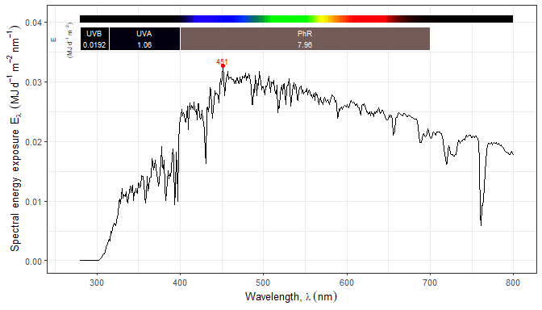

```r
autoplot(sun.daily.spct)
```

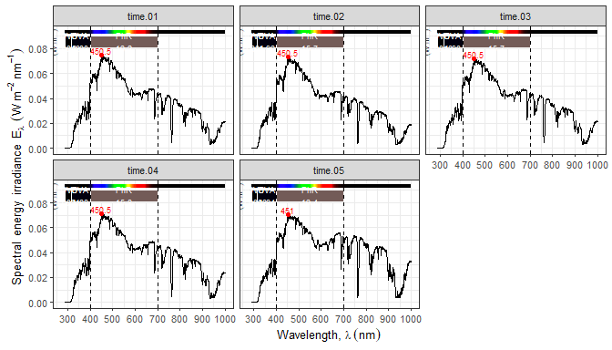

```r
autoplot(sun_evening.spct, facets = 3) +
  geom_vline(xintercept = c(400, 700), linetype = "dashed")
```

It is possible to construct and bind the spectra on-the-fly, and to use arbitrary variable names for the index factor. This works automatically as long as row binding is done with function `rbindspct()` which saves the name of the factor.

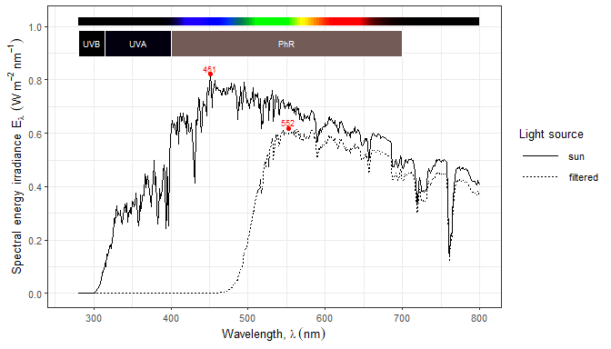

```r
filter_no_yes.spct <-
  rbindspct(list(sun = sun.spct, filtered = yellow_gel.spct * sun.spct),
            idfactor = "Light source")
autoplot(filter_no_yes.spct)
```

In the examples above the `source_spct` object `sun.spct` was used. The `autoplot()` methods for other spectral classes have only slight differences. We show some examples for `filter_spct` objects. For a long-pass filter the wavelength at half maximum is more interesting than peaks or valleys.

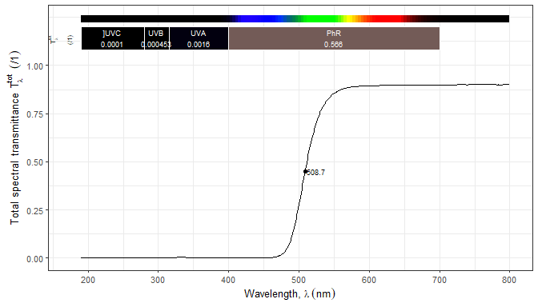

```r
autoplot(yellow_gel.spct,
         annotations = list(c("-", "peaks"), c("+", "wls")))
```

In many cases it is possible to convert on-the-fly the quantity plotted. In this case, given that the data are clipped as absorbance, a fixed target of A = 2 for the cut-off to be labelled with the wavelength is appropriate.

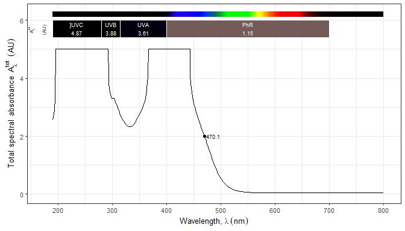

```r
autoplot(yellow_gel.spct, plot.qty = "absorbance", wls.target = 2,
         annotations = list(c("-", "peaks"), c("+", "wls")))
```

If one needs to, one can add a suitable layer function, *geom* or *stat*, using ‘local’ data, as shown here, or plot default data. A peak annotation could be added manually.

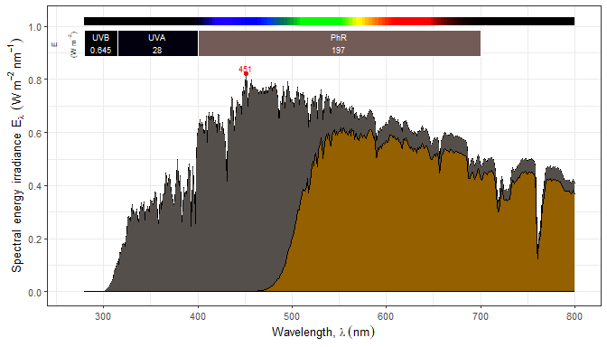

```r
autoplot(sun.spct) + geom_spct(fill = color_of(sun.spct)) +
  geom_spct(data = yellow_gel.spct * sun.spct, color = "black",
            fill = color_of(yellow_gel.spct * sun.spct))
```

In the case of quantities like transmittance which have a certain range of valid values, both upper and lower boundaries are highlighted, but in other cases only one, or even none depending on the possible valid ranges for the spectral quantities.

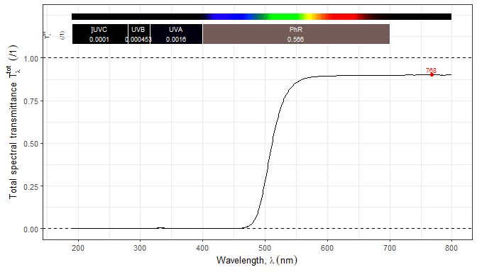

```r
autoplot(yellow_gel.spct, annotations = c("+", "boundaries"))
```

Differently from other classes `raw_spct` and `cps_spct` objects can contain multiple columns of data, normally measured different integration times, and meant to be combined before conversion into physical quantities. In the case of raw instrument counts data, if the spectral object contains an instrument descriptor as metadata, the upper boundary is set to the maximum counts of the detector.

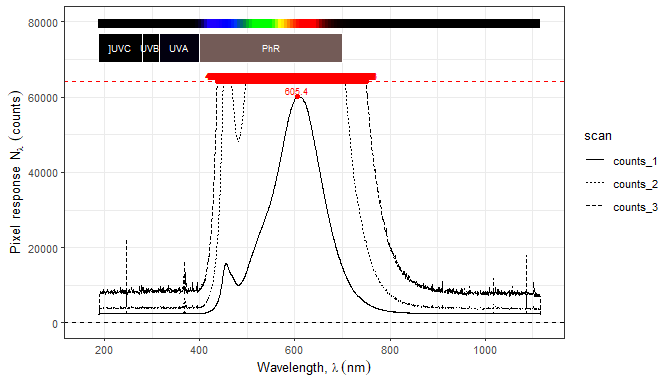

```r
autoplot(white_led.raw_spct, annotations = c("+", "boundaries"))
```

Both `raw_spct` and `cps_spct` objects contain multiple data columns when integration time bracketing has been used during data acquisition. In such cases, if one wants to plot only one of the raw spectra, one can extract the columns as usual in R using the extraction operator (`[ ]`). The single remaining column of spectral data is automatically renamed.

```r
autoplot(white_led.raw_spct[ , c("w.length", "counts_1")],
         annotations = c("+", "boundaries"))
```

[output not shown]

```r
autoplot(white_led.raw_spct[ , c("w.length", "counts_1", "counts_3")],
     annotations = c("+", "boundaries"))
```

[output not shown]

### Handling of off-range data

If the supplied data include off-range values such as negative irradiance or fractional transmittance, reflectance, or absorptance outside the zero to one range the exceeded boundary is highlighted in red.

```r
# Not run so as to pass CRAN checks!!
autoplot(yellow_gel.spct - 0.01, annotations = c("+", "boundaries"))
```

## Editing plots and adding layers

Using colors when adding to a plot generated by the `autoplot()` methods is more involved than usual, one has to take into account that the identity scale is in use for color in annotations, and a ggplot can make use of only one scale for a given aesthetic. For this same reason no color key in generated automatically.

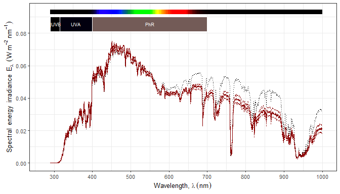

```r
autoplot(sun_evening.mspct, annotations = c("-", "peaks")) +
  aes(color = ifelse(spct.idx == "time.05", "black", "darkred")) +
  theme(legend.position = "none")
```

Plots created with `autoplot()` methods are `ggplot` objects and can be customized, bearing in mind that any added layers will be plotted on top or existing layers (that is unless we make use of methods from package ‘gginnards’ that allow insertion of layers at any position in a `ggplot` object).

Here we replace the default peaks annotations with a custom one, but still take advantage of other defaults like nice axis labels and other annotations.

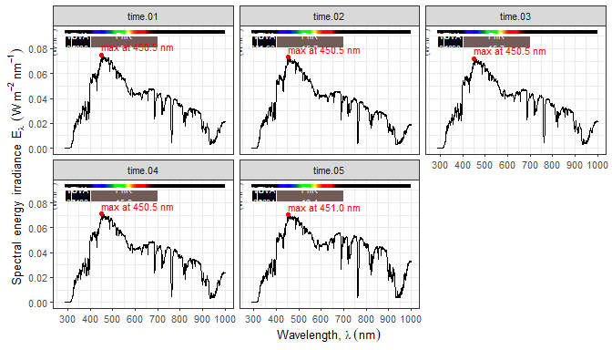

```r
autoplot(sun_evening.mspct, annotations = c("-", "peaks"), facets = TRUE) +
  stat_peaks(span = NULL, color = "red") +
  stat_peaks(span = NULL, geom = "text",
             label.fmt = "max at %3.1f nm",
             vjust = -0.5, hjust = 0,
             color = "red", size = 3)
```

## Ploting wavebands

A `autoplot()` method for `waveband` objects is also provided.

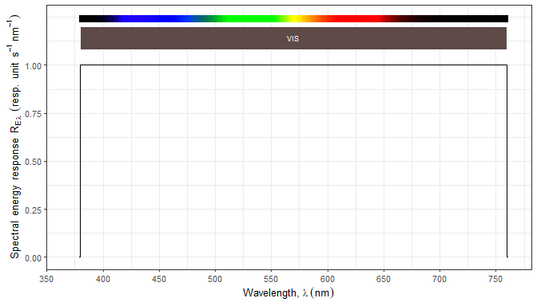

```r
autoplot(VIS())
```

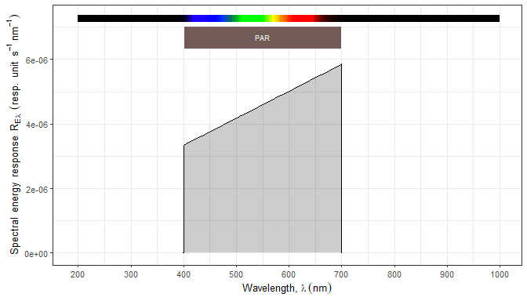

```r
autoplot(PAR(), range = c(200, 1000), geom = "spct",
         unit.in = "photon", unit.out = "energy")
```

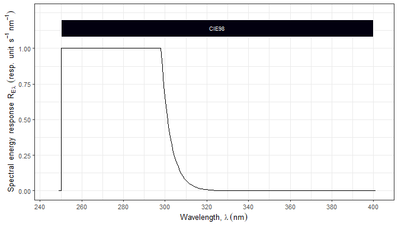

```r
autoplot(CIE(), range = CIE(), annotations = c("-", "color.guide"))
```

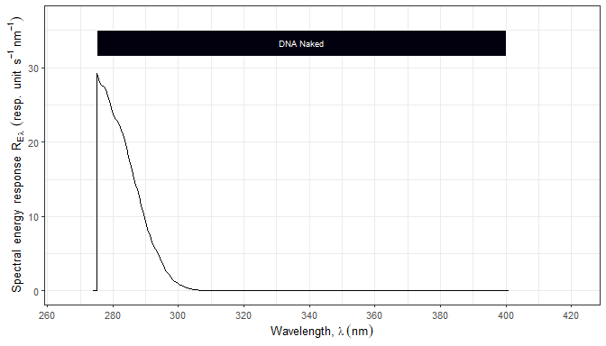

```r
autoplot(DNA_N(), range = c(270, 420), annotations = c("-", "color.guide"))
```